# Лабораторная работа №6

Дисциплина: Администрирование сетевых подсистем

Бахи сиди али темассини

1032234211@pfur.ru

Российский университет дружбы народов

2026-02-16

# Цель работы

## Цель работы

- Приобретение практических навыков установки и конфигурирования СУБД MariaDB

# Выполнение лабораторной работы

## Установка MariaDB

- Выполнен переход в режим суперпользователя
- Установлены пакеты `mariadb` и `mariadb-server` через `dnf`
- Подключены зависимости и компоненты сервера

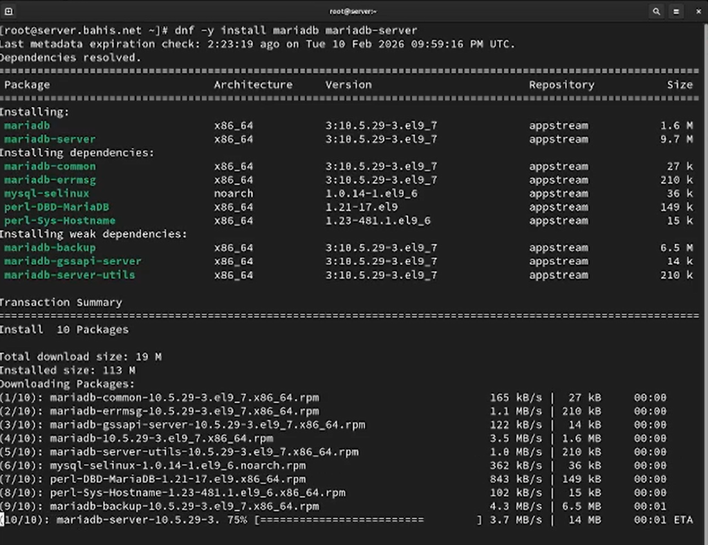

Рисунок 1: Установка пакетов mariadb и mariadb-server с помощью dnf

- Запущена служба `mariadb`
- Добавлена в автозагрузку (`enable`)
- Созданы символические ссылки systemd

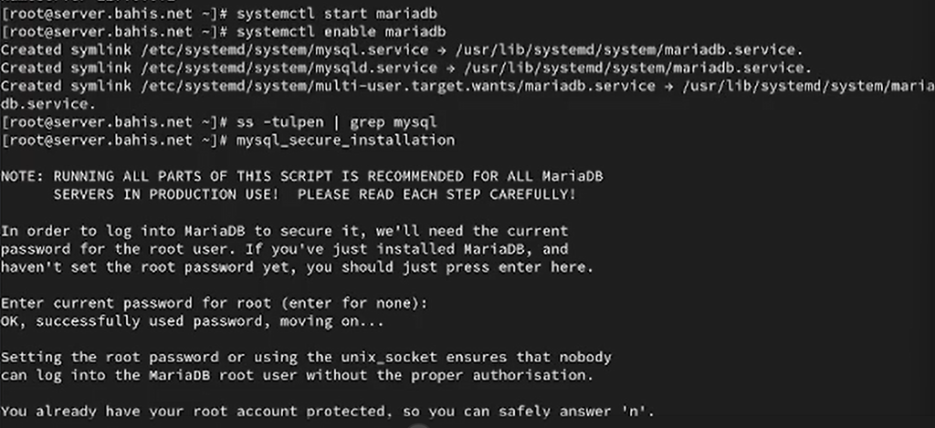

Рисунок 2: Запуск и включение службы mariadb через systemctl

[figure not shown]

- Выполнен `mysql_secure_installation`
- Включена аутентификация `unix_socket`
- Установлен пароль `root`
- Удалены анонимные пользователи
- Запрещён удалённый доступ root
- Удалена тестовая БД

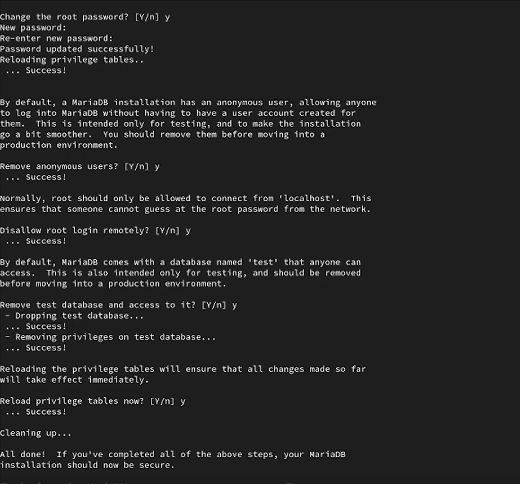

Рисунок 4: Выполнение mysql_secure_installation и настройка параметров безопасности

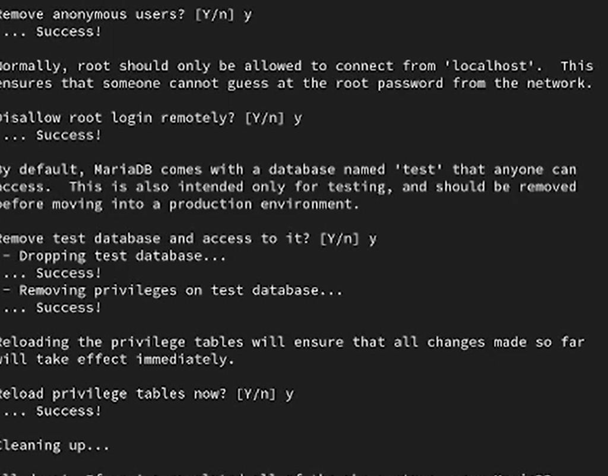

Рисунок 5: Выполнение mysql_secure_installation и настройка параметров безопасности

- Выполнен вход `mysql -u root -p`
- Отображена версия сервера

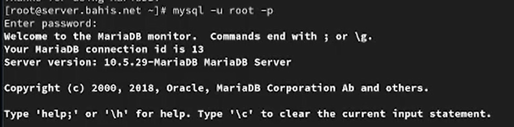

Рисунок 6: Вход в MariaDB под пользователем root

- Просмотр списка клиентских команд

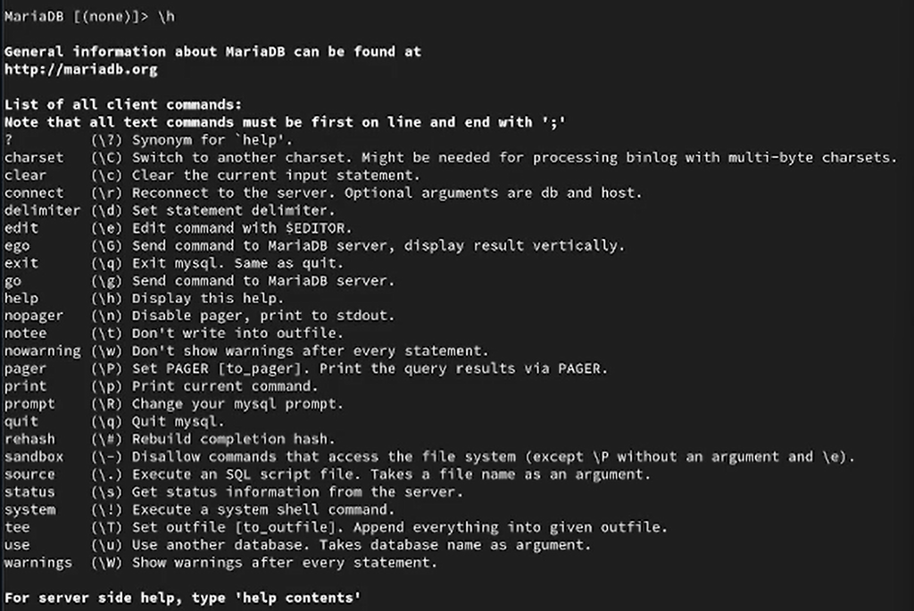

Рисунок 7: Список клиентских команд MariaDB

- Выполнен `SHOW DATABASES;`
- Отображены системные БД

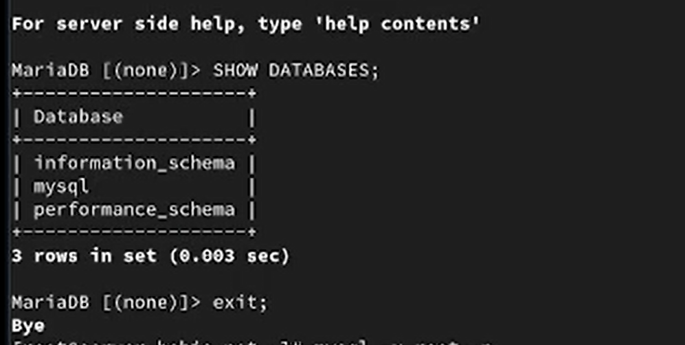

Рисунок 8: Отображение списка системных баз данных (SHOW DATABASES)

## Конфигурация кодировки символов

- Выполнен вход в MariaDB
- Команда `status` показала:
- Server characterset — `latin1`
- Db characterset — `latin1`
- Client — `utf8`

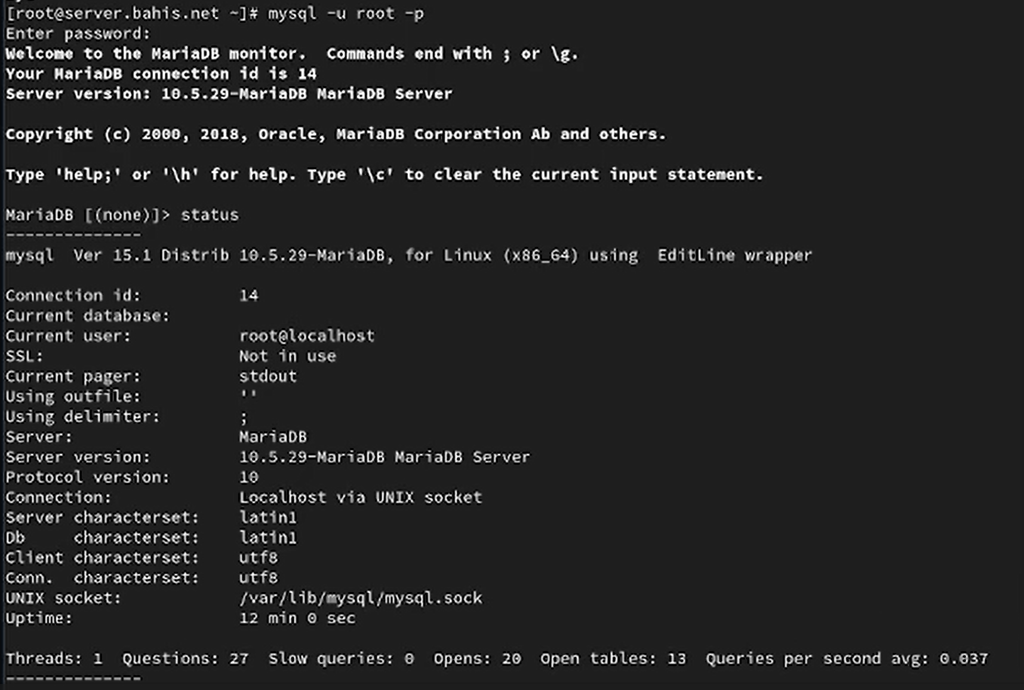

Рисунок 9: Вход в MariaDB и выполнение команды status (до изменения кодировки)

- Создан файл `/etc/my.cnf.d/utf8.cnf`

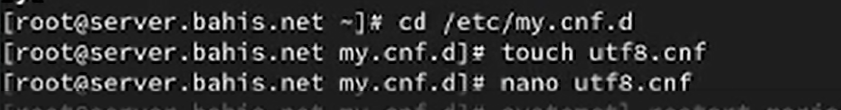

Рисунок 10: Создание файла utf8.cnf в каталоге /etc/my.cnf.d

- Добавлены параметры:
- `default-character-set = utf8`
- `character-set-server = utf8`

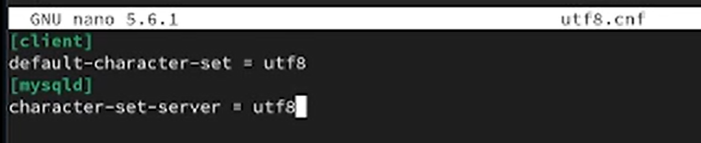

Рисунок 11: Содержимое файла utf8.cnf с параметрами кодировки UTF-8

- Перезапущена служба `mariadb`
- Повторно выполнен `status`
- Все параметры кодировки — `utf8`

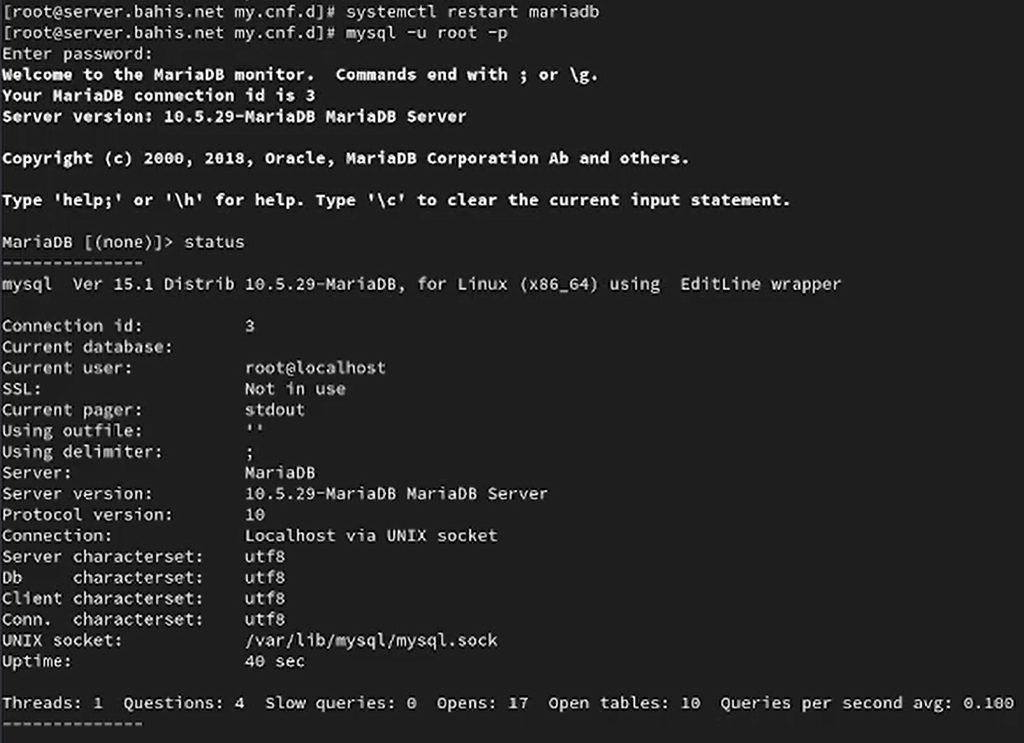

Рисунок 12: Проверка статуса MariaDB после изменения кодировки

## Создание базы данных

- Выполнен вход под `root`

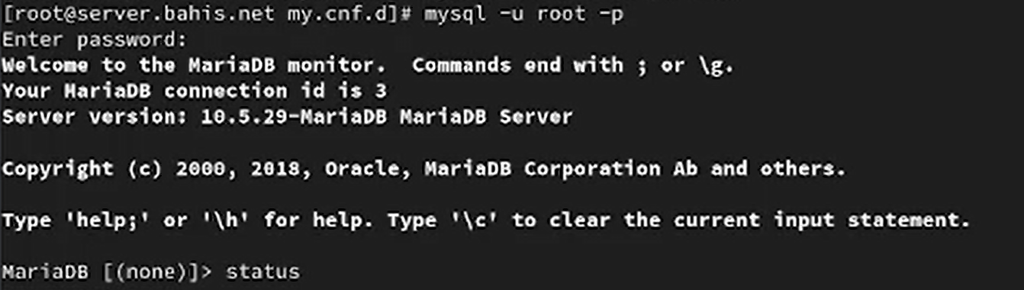

Рисунок 13: Вход в MariaDB под пользователем root

- Создана БД `addressbook` (`utf8`, `utf8_general_ci`)
- Выполнен `SHOW TABLES;` — таблицы отсутствуют

[figure not shown]

Рисунок 14: Создание базы данных addressbook и проверка списка таблиц

- Создана таблица `city` (`VARCHAR(40)`)
- Добавлены записи: Иванов, Петров, Сидоров
- Выполнен `SELECT * FROM city;`

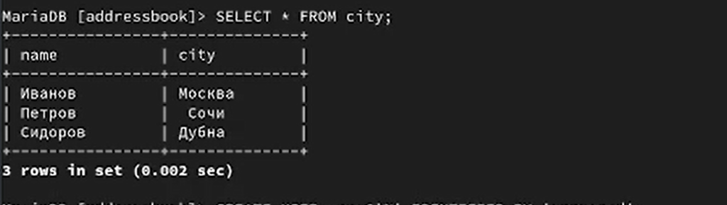

Рисунок 15: Создание таблицы city, вставка данных и результат SELECT * FROM city

- Создан пользователь `bahis@'%'`
- Назначены права `SELECT, INSERT, UPDATE, DELETE`
- Выполнен `FLUSH PRIVILEGES;`
- Проверена структура таблицы (`DESCRIBE city;`)

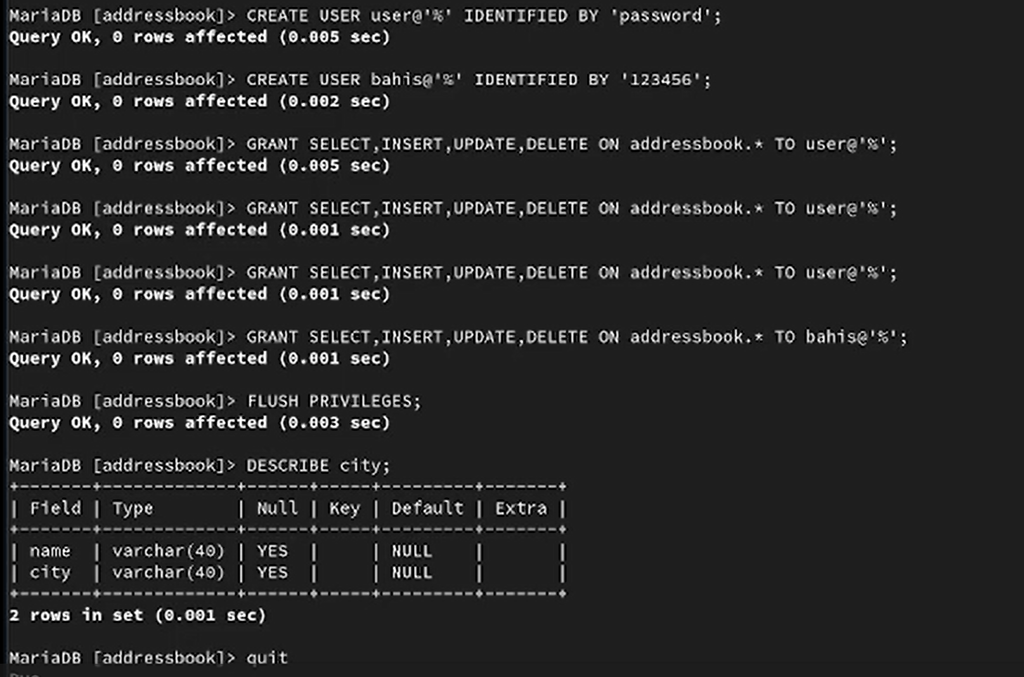

Рисунок 16: Создание пользователя, назначение прав и описание структуры таблицы city

- Проверка через `mysqlshow`
- База `addressbook` и таблица `city` доступны

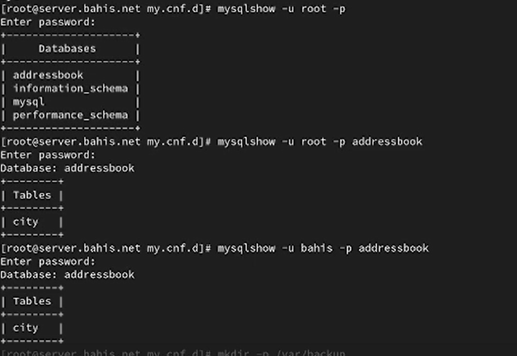

Рисунок 17: Просмотр баз данных и таблиц addressbook с помощью mysqlshow